# Statistical inference with the GSS data

## Setup

### Load packages

```r
library(ggplot2)
library(dplyr)
library(statsr)
```

### Load data

```r
load("gss.Rdata")
```

## Part 1: Data

This data is from the General Social Survey (GSS) Cumulative File 1972-2012 provides a sample of selected indicators in the GSS with the goal of providing a convenient data resource for students learning statistical reasoning using the R language. This data has already been preprocessed with many NA values are removed. Since this data is collected from randomly selected people for survey questions. Thus these results can only be generalized, instead of establish a causal relationship.

## Part 2: Research question

The question that I want to focus on this report is that what is proportion of peopel with higher education (college and graduate level above) compared with their races. Is it true that white people has larger higher education ratio than black people.

This question is interesting, because I think it is related to recent movement of political correct in US. Is it statistical correct that white people has higher education level than black people. As seen in previous section that there is only three groups of races included in the data sets - “white, black, other”. But in this study, I will only focus on two groups of people, “white and black” only. Because other races include hispanic groups, asians etc. These people only count for a small protion of the data sets, thus I will ignore them, only focus on “white and black” groups.

## Part 3: Exploratory data analysis

Now I will focus on the race and the degree columns of this data sets.

```r
summary(gss$race)
```

```
## White Black Other
## 46350  7926  2785
```

```r
summary(gss$degree)
```

```
## Lt High School    High School Junior College       Bachelor       Graduate
##          11822          29287           3070           8002           3870
##           NA's
##           1010
```

As we can see that there are three races in this data sets. Basically white, black and other, with there are much more white person than black or others. For the degree category, there are several categories. But I will only focus on the ratio of higher education rates, which is what fraction of population in the survey races have bachelor degree or higher, meanwhile I will remove the NA people in the degree columns. First I will plot the basic graph of race and degrees with different degree level is labeled out.

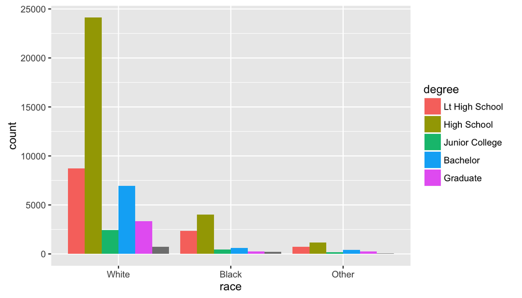

```r
 ggplot(gss, aes(x = race, fill = degree)) +
     geom_bar(position='dodge')
```

```r
table(gss$race,gss$degree)
```

```
##
##         Lt High School High School Junior College Bachelor Graduate
##   White           8732       24129           2420     6961     3360
##   Black           2365        4001            464      616      270
##   Other            725        1157            186      425      240
```

It’s clear from this plot that most people has high school diploma, while less fraction of people has bachelor degree or higher. Now from the previous table I can combine the numbers and create new variable with higher education degree “Yes” or “No”. Then I can calculate the proportional of people with higher education degree for only group “white” and “black”.

```r
t_white<-6961+3360+8732+24129+2420
h_white<-6961+3360
t_black<-616+270+2365+4001+464
h_black<-616+270

prop_white<-h_white/t_white
prop_black<-h_black/t_black
prop_white
```

```
## [1] 0.2263278
```

```r
prop_black
```

```
## [1] 0.1148263
```

Now from previous data that the proportional of white people with higher educational degree is 0.2263, white for black people is only 0.1148. The difference of proportion in the survey is 0.11. Looks significant, but next I will focus on the statistical inferences and see that if this difference of proportion is due to chance or it is really different for these two groups.

## Part 4: Inference

#### Hypothesis

Let me denote that p1’ is proportion of white people with higher educational degree in the sample survey data. p2’ is proportion of black people with higher educational degree in the survey.

Thus p1’=0.2263, p2’=0.1148.

p1 and p2 is the proportion for the whole population that we want to study with inference.

As we learned from the class, the null hypothesis is that nothing is going on here,  
while alternative hypothesis is that something is going on.

1. H0: p1$=$p2,
2. HA: p1$\neq$p2.

#### check the condition for inferences

Now I will check the conditions of hypothesis test for the two proportion inferences. First we need the pool proportion and calculate the successful-failure condition.

```r
p_pool<-(h_white+h_black)/(t_white+t_black)
p_pool
```

```
## [1] 0.2101917
```

```r
t_white*p_pool>10
```

```
## [1] TRUE
```

```r
t_white*(1-p_pool)>10
```

```
## [1] TRUE
```

```r
t_black*p_pool>10
```

```
## [1] TRUE
```

```r
t_black*(1-p_pool) >10
```

```
## [1] TRUE
```

```r
se<-sqrt((p_pool*(1-p_pool)/t_black)+(p_pool*(1-p_pool)/t_white))
se
```

```
## [1] 0.005015538
```

As we can see that both pooled proportion the success and failure for white and black people are both larger than 10. Thus it is safe for us to use the proportion statistical inferences. With standard error is 0.005. Now in our data point of estimate is

1. p1’-p2’= 0.1115.
2. Null value = 0
3. standard error se=0.005

Next we can find the Z score and calculate the p value.

```r
Z<-(prop_white-prop_black-0)/se
p_value<-2*pnorm(Z,lower.tail = FALSE)
p_value
```

```
## [1] 1.714582e-109
```

As we can see that p_value is much smaller than 0.05, which means we should reject the null hypothesis, which means there is a diffference between higher education proportion for white and black races.

If we want to do the test for confidence level, it is alreay shown in previous data, that both groups the success and failure people (with and without higher education people) has more than 10 people. Then we can compare with the 95% confidence interval and see if these results match with inferences from p_value.

```r
se2<-sqrt((prop_black*(1-prop_black)/t_black)+(prop_white*(1-prop_white)/t_white))
(prop_white-prop_black)+1.96*se2
```

```
## [1] 0.1195857
```

```r
(prop_white-prop_black)-1.96*se2
```

```
## [1] 0.1034172
```

Here the 95% confidence interval of proportion difference is between

##### [0.1034 ~ 0.1196].

It’s clearly see that the null hypothesis for difference of p1-p2=0 is not inside this interval. Therefore, it has statistical significance that there is a difference between higher education proportion for white and black races.

### 5. Summary and future directions.

In this study I provide with very solid results by comparing the proportions of higher education for two races “black” and “white”. In the sample, the difference of proportion is 0.1115. And the condition for hypothesis test and confidence interval are both met. The p_value is much smaller than 0.05, while the 95% confidence interval do not include 0. All these results are consistent that there is statistical significance that there are differences in the proportions of higher education for two races “black” and “white”.

Future research could extend this study to more race groups, since in this survey data, “other” group could possible include asian, hispanic and many other races in the us. It’s interesting to find out which race has the highest proportions of higher education. Some drawbacks of this study is that it the sample correctly included the race structure of population in the US. In the survey data, white people is much more than other groups by a factor of 5. But it is survey sample a good representation of all the US population structure. We can do chi-squre test to find out.